# 2019.02 Ford Go Bike - tripdata

## by Szymon Debski

## Investigation Overview

> The exploration and visualization purpose is to find a pattern in bike riding history, mainly focusing on ride duration and characteristics of people riding the bike.

## User Type by Weekday bike use

> As we can see from the first graph most of the people using the service are Subscribers 90.7% the rest are random customers 9.3%.

> In the second graph we can see an interesting observation - during the working week proportionally subscribers used the service more, however, on the weekend regular (random) customer used it proportionally more often. This means that on the weekend many casual bike riders use the service and people that use it during the week for commuting don't use the service as often.

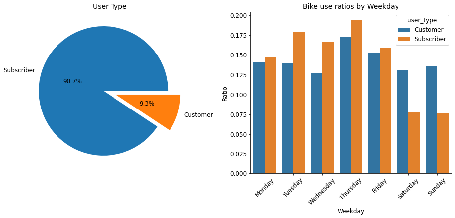

```python
plt.figure(figsize=(16,6))
plt.subplot(1, 2, 1)
vals = df.user_type.value_counts()/df.shape[0]
labels = vals.keys()
plt.pie(x=vals, autopct="%.1f%%", explode=[0.1]*2, labels=labels, pctdistance=0.5)
plt.title("User Type", fontsize=14);
plt.subplot(1, 2, 2)
sb.barplot(x='weekday', y='ratio', hue='user_type', data=ratios);
plt.xlabel('Weekday');
plt.ylabel('Ratio');
plt.xticks(rotation = 45);
plt.title("Bike use ratios by Weekday", fontsize=14);
```

## Bike user count by Gender and time of day the bike was rented

> The hour at which the bikes are rented is also interesting. We can see that people mostly use the bikes around 8 AM and 5 PM. This indicates that the main way people use the bike is for commuting.

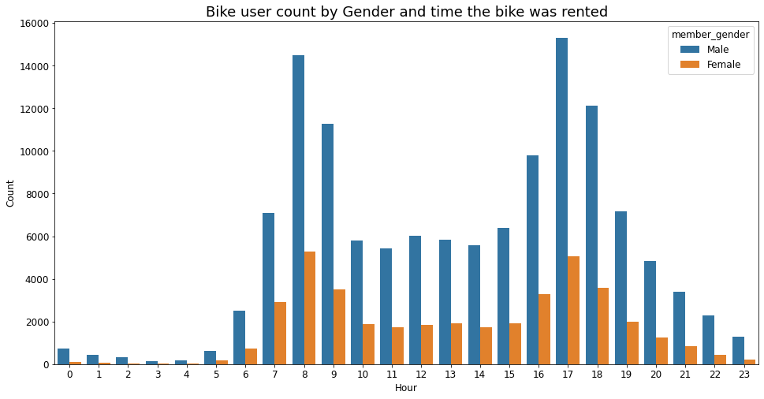

```python
fig = plt.figure(figsize = [16,8])
sb.countplot(data = df, x = 'hour', hue = 'member_gender');
plt.xlabel('Hour');
plt.ylabel('Count');
plt.title("Bike user count by Gender and time the bike was rented", fontsize=18);
```

## Bike rental time by gender and age

> Below we can see an interesting observation. We can verify that female bike riders tend to rent the bike for longer. Also, we can verify that the youngest people rent the bike for longer periods. However, one interesting thing to note is that people that are older than 50 years tend to rent the bike for longer periods compared to 30 - 50-year-olds. This is a very interesting observation which may indicate the people after 50 use the bike more for exercise as a fitness tool as opposed to a commuting tool.

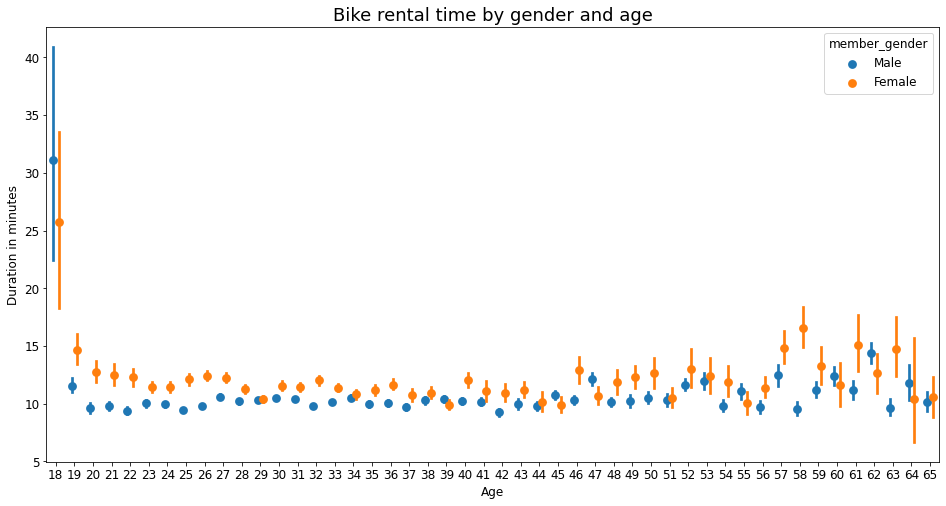

```python
fig = plt.figure(figsize = [16,8])
sb.pointplot(data=df, x='age', y='duration_minutes', hue='member_gender', dodge=0.3, linestyles="");
plt.xlabel('Age');
plt.ylabel('Duration in minutes');
plt.title("Bike rental time by gender and age", fontsize=18);
```